# A&E Attendances Dataset

Published

18 December 2022

# The A&E Attendances Dataset

This report explains how to use the `ae_attendances` dataset from the [{NHSRdatasets}](https://nhs-r-community.github.io/NHSRdatasets/) package. The dataset contains all reported A&E attendances for the period April 2016 through March 2019.

First let’s open and explore the dataset to show the first 10 rows of data.

**A&E Attendances**

```r
# load dataset and create formatted table
# -------------------------------------------------------------------------
suppressPackageStartupMessages({
  library(dplyr)
  library(readr)
})
# library(NHSRdatasets)
# data(ae_attendances)

# set data path
data_path <- "data"
start_state <- "raw"
source <- "NHSRdatasets"
source_file <- "ae_attendances.csv"

# load data
metric_path <- here(data_path, start_state, source)
ae_attendances <- readr::read_csv(here(metric_path, source_file),
                                  show_col_types = FALSE)

# format and create table
ae_attendances %>%
  # set the period column to show in Month-Year format
  dplyr::mutate_at(vars(period), format, "%b-%y") %>%
  # set the numeric columns to have a comma at the 1000's place
  dplyr::mutate_at(vars(attendances, breaches, admissions), comma) %>%
  # show the first 10 rows
  head(10) %>%
  # format as a table
  knitr::kable()
```

| period | org_code | type | attendances | breaches | admissions |
| --- | --- | --- | --- | --- | --- |
| Mar-17 | RF4 | 1 | 21,289 | 2,879 | 5,060 |
| Mar-17 | RF4 | 2 | 813 | 22 | 0 |
| Mar-17 | RF4 | other | 2,850 | 6 | 0 |
| Mar-17 | R1H | 1 | 30,210 | 5,902 | 6,943 |
| Mar-17 | R1H | 2 | 807 | 11 | 0 |
| Mar-17 | R1H | other | 11,352 | 136 | 0 |
| Mar-17 | AD913 | other | 4,381 | 2 | 0 |
| Mar-17 | RYX | other | 19,562 | 258 | 0 |
| Mar-17 | RQM | 1 | 17,414 | 2,030 | 3,597 |
| Mar-17 | RQM | other | 7,817 | 86 | 0 |

**Reference**

**Data source**

- [NHS England Statistical Work Areas](https://www.england.nhs.uk/statistics/statistical-work-areas/ae-waiting-times-and-activity/)
- available under the [Open Government Licence v3.0](https://www.nationalarchives.gov.uk/doc/open-government-licence/version/3/)

The dataset contains:

- `period`: the month that this activity relates to, stored as a date (1st of each month)
- `org_code`: the [ODS](https://digital.nhs.uk/services/organisation-data-service) code for the organisation that this activity relates to
- `type`: the [Department Type](https://web.archive.org/web/20200128111444/https://www.datadictionary.nhs.uk/data_dictionary/attributes/a/acc/accident_and_emergency_department_type_de.asp) for this activity, either 1, 2, or other
- `attendances`: the number of attendances for this department type at this organisation for this month
- `breaches`: the number of attendances that breached the 4 hour target
- `admissions`: the number of attendances that resulted in an admission to the hospital

## England A&E 4 hours Performance

We can calculate the 4 hours performance for England as a whole like so:

**England 4 Hours Performance**

```r
england_performance <- ae_attendances %>%
  group_by(period) %>%
  summarise_at(vars(attendances, breaches), sum) %>%
  mutate(performance = 1 - breaches / attendances)

# format for display
england_performance %>%
  # same format options as above
  mutate_at(vars(period), format, "%b-%y") %>%
  mutate_at(vars(attendances, breaches), comma) %>%
  # this time show the performance column as a percentage
  mutate_at(vars(performance), percent) %>%
  # show the first 10 rows and format as a table
  head(10) %>%
  knitr::kable()
```

| period | attendances | breaches | performance |
| --- | --- | --- | --- |
| Apr-16 | 1,867,781 | 186,122 | 90.0351% |
| May-16 | 2,070,340 | 201,329 | 90.2756% |
| Jun-16 | 1,958,802 | 184,912 | 90.5599% |
| Jul-16 | 2,079,034 | 201,973 | 90.2852% |
| Aug-16 | 1,932,901 | 174,419 | 90.9763% |
| Sep-16 | 1,952,464 | 182,597 | 90.6479% |
| Oct-16 | 2,001,816 | 219,137 | 89.0531% |
| Nov-16 | 1,907,871 | 221,713 | 88.3790% |
| Dec-16 | 1,944,567 | 268,818 | 86.1759% |
| Jan-17 | 1,895,272 | 281,612 | 85.1413% |

We can now plot the monthly performance

**England A&E Performance**

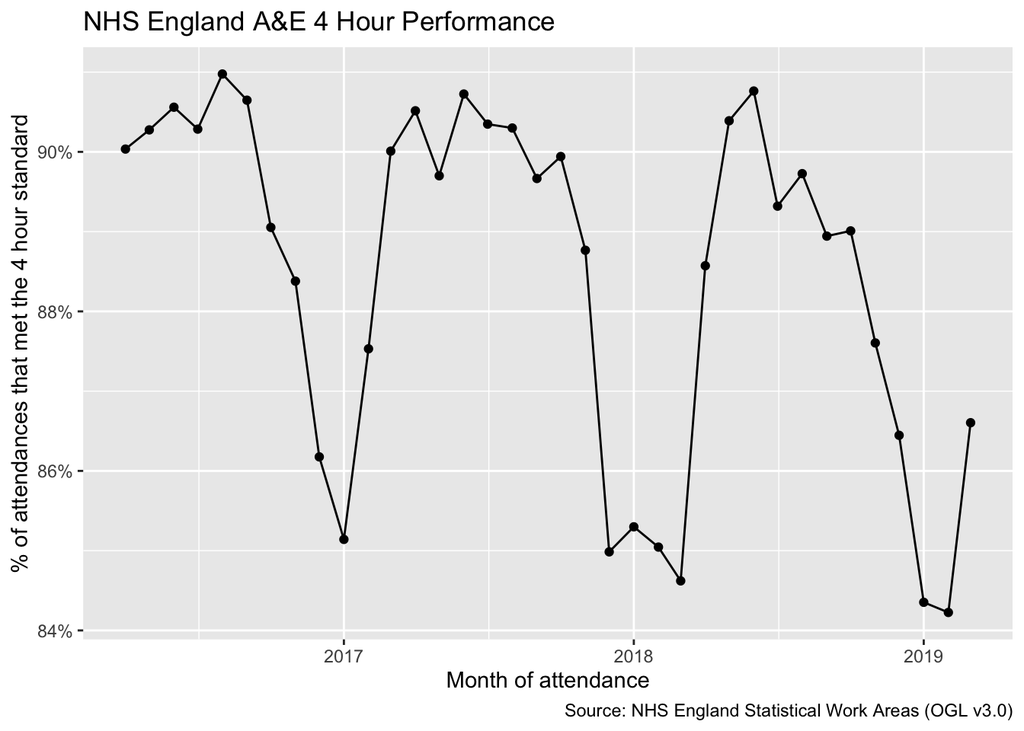

```r
ggplot(england_performance, aes(period, performance)) +
  geom_line() +
  geom_point() +
  scale_y_continuous(labels = percent) +
  labs(x = "Month of attendance",
       y = "% of attendances that met the 4 hour standard",
       title = "NHS England A&E 4 Hour Performance",
       caption = "Source: NHS England Statistical Work Areas (OGL v3.0)")
```

We can clearly see the “Winter Pressures” where performance drops.

## Performance by Trust Type

We can also inspect performance for the [different types of department](https://web.archive.org/web/20200128111444/https://www.datadictionary.nhs.uk/data_dictionary/attributes/a/acc/accident_and_emergency_department_type_de.asp):

**England Performance by Type**

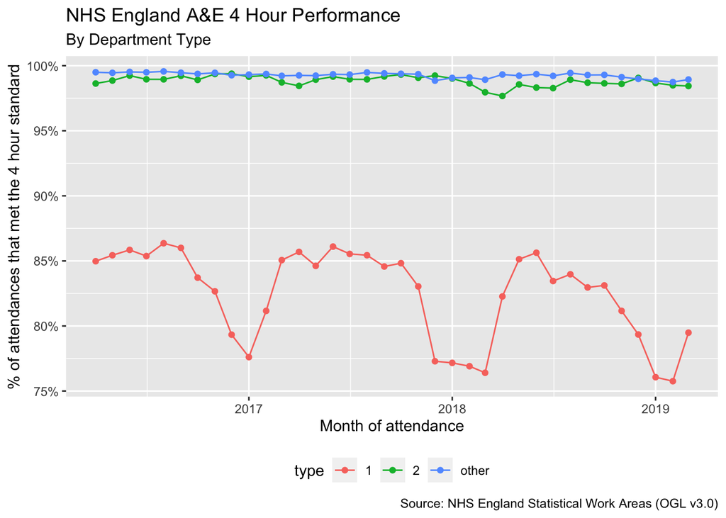

```r
ae_attendances %>%
  group_by(period, type) %>%
  summarise_if(is.numeric, sum) %>%
  mutate(performance = 1 - breaches / attendances) %>%
  ggplot(aes(period, performance, colour = type)) +
  geom_line() +
  geom_point() +
  scale_y_continuous(labels = percent) +
  #facet_wrap(vars(type), nrow = 1) +
  theme(legend.position = "bottom") +
  labs(x = "Month of attendance",
       y = "% of attendances that met the 4 hour standard",
       title = "NHS England A&E 4 Hour Performance",
       subtitle = "By Department Type",
       caption = "Source: NHS England Statistical Work Areas (OGL v3.0)")
```

**Reference**

According to the [NHS Data Dictonary](https://web.archive.org/web/20200128111444/https://www.datadictionary.nhs.uk/data_dictionary/attributes/a/acc/accident_and_emergency_department_type_de.asp) the type of Accident and Emergency Department is determined according to the activity performed as follows:

### National Codes:

- `01`: Emergency departments are a Consulatant led 24 hour service with full resuscitation facilities and designated accommodation for the reception of accident and emergency Patients
- `02`: Consultant led mono specialty accident and emergency service (e.g. ophthalmology, dental) with designated accommodation for the reception of Patients
- `03`: Other type of A&E/minor injury activity with designated accommodation for the reception of accident and emergency Patients. The department may be doctor led or NURSE led and treats at least minor injuries and illnesses and can be routinely accessed without appointment. A service mainly or entirely appointment based (for example a GP Practice or Out-Patient Clinic) is excluded even though it may treat a number of Patients with minor illness or injury. Excludes NHS walk-in centres
- `04`: NHS walk in centres

From this it appears as if only the type 1 departments have the seasonal drops, type 2 and “other” departments remain pretty consistent.

## Best and worst for performance?

We could create a similar table of data for performance by each individual trust, but it would be useful to only look at trusts that have a type 1 department as it appears from the chart above that these departments have the largest variation.

**Performance by Trust**

```r
performance_by_trust <- ae_attendances %>%
  group_by(org_code, period) %>%
  # make sure that this trust has a type 1 department
  filter(any(type == 1)) %>%
  summarise_at(vars(attendances, breaches), sum) %>%
  mutate(performance = 1 - breaches / attendances)

# format for display
performance_by_trust %>%
  mutate_at(vars(period), format, "%b-%y") %>%
  mutate_at(vars(attendances, breaches), comma) %>%
  mutate_at(vars(performance), percent) %>%
  head(10) %>%
  knitr::kable()
```

| org_code | period | attendances | breaches | performance |
| --- | --- | --- | --- | --- |
| R0A | Oct-17 | 35,744 | 3,663 | 89.7521% |
| R0A | Nov-17 | 34,314 | 3,982 | 88.3954% |
| R0A | Dec-17 | 34,082 | 5,430 | 84.0678% |
| R0A | Jan-18 | 33,758 | 4,906 | 85.4671% |
| R0A | Feb-18 | 30,520 | 4,111 | 86.5301% |
| R0A | Mar-18 | 35,233 | 5,496 | 84.4010% |
| R0A | Apr-18 | 33,127 | 3,809 | 88.5018% |
| R0A | May-18 | 35,797 | 4,792 | 86.6134% |
| R0A | Jun-18 | 34,070 | 3,616 | 89.3866% |
| R0A | Jul-18 | 35,081 | 4,723 | 86.5369% |

From this table we can calculate the overall performance by each trust and then organise the trusts by their overall performance.

```r
performance_by_trust_ranking <- performance_by_trust %>%
  summarise(performance = 1 - sum(breaches) / sum(attendances)) %>%
  arrange(performance) %>%
  pull(org_code) %>%
  as.character()

### Top Performing Trusts
tail(performance_by_trust_ranking, 5)
```

```
[1] "RA4" "RBD" "RVW" "RCU" "RC9"
```

```r
### Bottom Performing Trusts
head(performance_by_trust_ranking, 5)
```

```
[1] "RQW" "RWD" "RXW" "RX1" "RHU"
```

[figure not shown]

```r
performance_by_trust %>%
  ungroup() %>%
  mutate_at(vars(org_code), fct_relevel, performance_by_trust_ranking) %>%
  filter(org_code %in% c(head(performance_by_trust_ranking, 5))) %>%
  ggplot(aes(period, performance)) +
  geom_line() +
  geom_point() +
  scale_y_continuous(labels = percent) +
  facet_wrap(vars(org_code), nrow = 2) +
  theme(legend.position = "bottom") +
  labs(x = "Month of attendance",
       y = "% of attendances that met the 4 hour standard",
       title = "NHS England A&E 4 Hour Performance",
       subtitle = "Top 5 over the whole 3 years",
       caption = "Source: NHS England Statistical Work Areas (OGL v3.0)")
```

[figure not shown]

```r
performance_by_trust %>%
  ungroup() %>%
  mutate_at(vars(org_code), fct_relevel, performance_by_trust_ranking) %>%
  filter(org_code %in% c(tail(performance_by_trust_ranking, 5))) %>%
  ggplot(aes(period, performance)) +
  geom_line() +
  geom_point() +
  scale_y_continuous(labels = percent) +
  facet_wrap(vars(org_code), nrow = 2) +
  theme(legend.position = "bottom") +
  labs(x = "Month of attendance",
       y = "% of attendances that met the 4 hour standard",
       title = "NHS England A&E 4 Hour Performance",
       subtitle = "Bottom 5 over the whole 3 years",
       caption = "Source: NHS England Statistical Work Areas (OGL v3.0)")
```

## Benchmarking

It is sometimes useful to see how an organisation stacks up against all of the other organisations. Below we create a chart where each organisation is shown as a point, ordered by performance from left (highest performance) to right (lowest) performance.

It’s useful to indicate certain organisations on the chart, below I am showing the 3 organisations that are at the lower quartile, median and upper quartile, however you could change this to instead pick out specific organisations (using a reference table and `left_join` or hard coding with `case_when`).

**Performance Spine Chart**

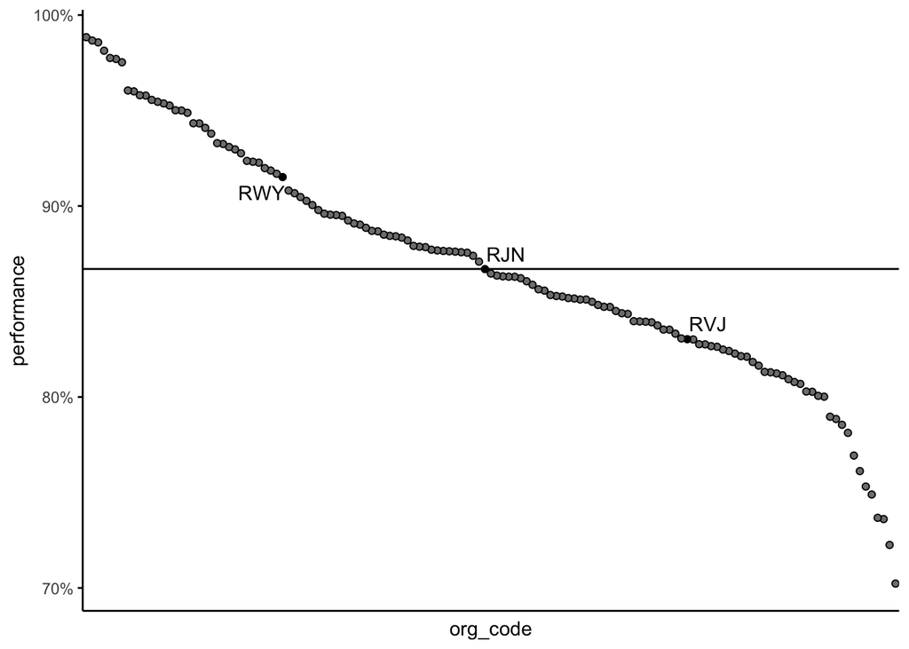

```r
ae_attendances %>%
  filter(period == last(period)) %>%
  group_by(org_code) %>%
  filter(any(type == 1)) %>%
  summarise_at(vars(attendances, breaches), sum) %>%
  mutate(performance = 1 - breaches/attendances,
         overall_performance = 1 - sum(breaches)/sum(attendances),
         org_code = fct_reorder(org_code, -performance)) %>%
  #
  arrange(performance) %>%
  # lets highlight the organsiations that are at the lower and upper quartile
  # and at the median. First "tile" the data into 4 groups, then we use the
  # lag function to check to see if the value changes between rows. We will get
  # NA for the first row, so replace this with FALSE
  mutate(highlight = ntile(n = 4),
         highlight = replace_na(highlight != lag(highlight), FALSE)) %>%

  ggplot(aes(org_code, performance)) +
  geom_hline(aes(yintercept = overall_performance)) +
  geom_point(aes(fill = highlight), show.legend = FALSE, pch = 21) +
  geom_text_repel(aes(label = ifelse(highlight, as.character(org_code), NA)),
                  na.rm = TRUE) +
  scale_fill_manual(values = c("TRUE" = "black",
                               "FALSE" = NA)) +
  scale_y_continuous(labels = percent) +
  theme_minimal() +
  theme(panel.grid = element_blank(),
        axis.text.x = element_blank(),
        axis.line = element_line(),
        axis.ticks.y = element_line())
```

# Footnotes

Adapted from the vignette in the [{NHSRdatasets}](https://nhs-r-community.github.io/NHSRdatasets/) package, writen by Thomas Jemmett and developed by the [NHS-R Community](https://nhsrcommunity.com/).